# SAN GLMS AND VISUALISATIONS

2024-20-12

```r
library(tidyverse)
library(car)         # multicollinearity
library(lmtest)      # heteroskedasticity
library(MASS)        # stepwise regression
library(caret)       # model evaluation
library(glmnet)      # LASSO
library(AER)
```

```r
library(dplyr)       # all_of()
library(ggplot2)     # plotting
library(tidyr)       # plotting
```

Ideas for observations - is there relationship between non-germans and specific crime types

possible reduced: total.offenses..recorded.cases, bodily.injury..sects..223.227..229..231.PC…recorded.cases, offenses.against.life..recorded.cases, murder..sect..211.PC…recorded.cases, robbery..extortion.resembling.robbery..and.assault.on.motorists.with.intent.to.rob..sects..249.252..255..316a.PC…recorded.cases, handbag.robbery..recorded.cases, bodily.injury..sects..223.227..229..231.PC…recorded.cases, serious.shoplifting..recorded.cases, street.crime..recorded.cases, unauthorised.trafficking..production.of..dispensing..and.possession.of.drugs..Sect..29a..1..no..2.NCA…significant.amount…recorded.cases

alternate columns: total.offenses..number.of.non.German.suspects, offenses.against.life..number.of.non.German.suspects, murder..sect..211.PC…number.of.non.German.suspects, robbery..extortion.resembling.robbery..and.assault.on.motorists.with.intent.to.rob..sects..249.252..255..316a.PC…number.of.non.German.suspects, handbag.robbery..number.of.non.German.suspects, bodily.injury..sects..223.227..229..231.PC…number.of.non.German.suspects, serious.shoplifting..number.of.non.German.suspects, street.crime..number.of.non.German.suspects

YEARLY DATA ANALYSIS_______________________________________________________

```r
# Load data
data <- read.csv("final.csv")

#selection simple table
total_cases_table <- data %>%
  dplyr::select(
    total.offences..recorded.cases,
    bodily.injury..sects..223.227..229..231.PC...recorded.cases,
    offences.against.life..recorded.cases,
    murder..sect..211.PC...recorded.cases,
    robbery..extortion.resembling.robbery..and.assault.on.motorists.with.intent.to.rob..sects..249.252..255..316a.PC...recorded.cases,
    handbag.robbery..recorded.cases,
    bodily.injury..sects..223.227..229..231.PC...recorded.cases,
    serious.shoplifting..recorded.cases,
    street.crime..recorded.cases,
    unauthorised.trafficking..production.of..dispensing..and.possession.of.drugs..Sect..29a..1..no..2.NCA...significant.amount...recorded.cases,
    property.and.forgery.offences..recorded.cases
  )

# Second table: Select columns related to non-German suspects
non_german_suspects_table <- data %>%
  dplyr::select(
    total.offences..number.of.non.German.suspects,
    bodily.injury..sects..223.227..229..231.PC...number.of.non.German.suspects,
    offences.against.life..number.of.non.German.suspects,
    murder..sect..211.PC...number.of.non.German.suspects,
    robbery..extortion.resembling.robbery..and.assault.on.motorists.with.intent.to.rob..sects..249.252..255..316a.PC...number.of.non.German.suspects,
    handbag.robbery..number.of.non.German.suspects,
    bodily.injury..sects..223.227..229..231.PC...number.of.non.German.suspects,
    serious.shoplifting..number.of.non.German.suspects,
    street.crime..number.of.non.German.suspects,
    unauthorised.trafficking..production.of..dispensing..and.possession.of.drugs..Sect..29a..1..no..2.NCA...significant.amount...number.of.non.German.suspects,
    property.and.forgery.offences..number.of.non.German.suspects
  )

#what percentage of the crime was done by non_germans
non_german_percentage <- (non_german_suspects_table / total_cases_table) * 100
non_german_percentage$Year <- 2014:2023
```

VISUALISING CRIME DISTRIBUTION BY MONTH__________________

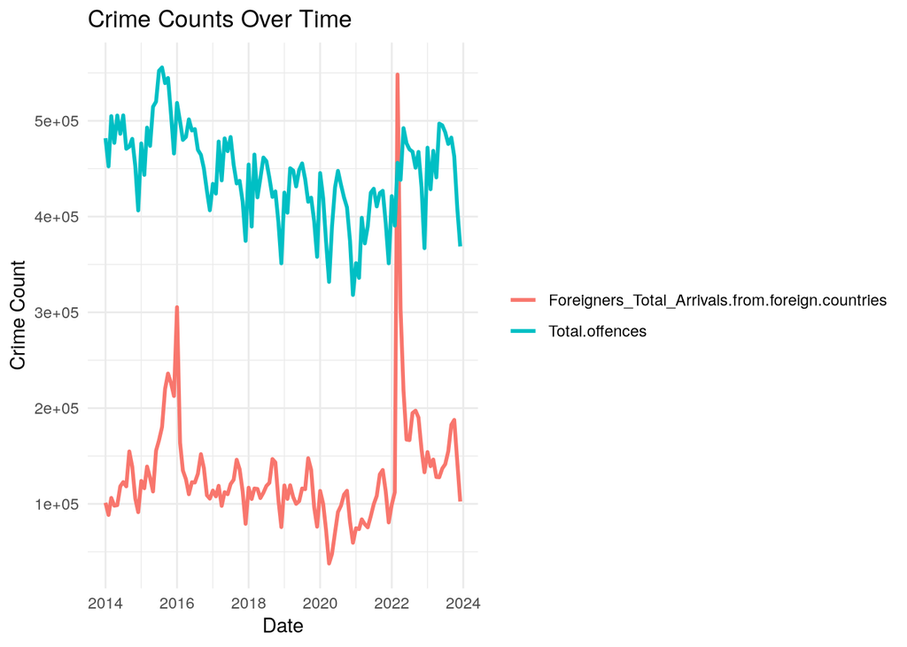

```r
data_monthly <- read.csv("monthly.csv")
data_cleaned <- na.omit(data_monthly)
data_crime_months <- data_cleaned %>%
  dplyr::select(
    Date,
    Total.offences,
    Foreigners_Total_Arrivals.from.foreign.countries,
  )

data_crime_months$Date <- as.Date(data_crime_months$Date)

data_crime_months$Month <- format(data_crime_months$Date, "%b")  # Abbreviated month (Jan, Feb, etc.)
data_crime_months$Year <- format(data_crime_months$Date, "%Y")  # Extract year if needed


data_crime_long <- data_crime_months %>%
  pivot_longer(-c(Date, Month, Year), names_to = "Crime_Type", values_to = "Count")

ggplot(data_crime_long, aes(x = as.Date(Date), y = Count, color = Crime_Type)) +
  geom_line(size = 1) +
  labs(title = "Crime Counts Over Time", x = "Date", y = "Crime Count") +
  theme_minimal() +
  theme(legend.title = element_blank())
```

```r
monthly_crime <- data_crime_long %>%
  group_by(Month, Crime_Type) %>%
  summarise(Average_Count = mean(Count))
```

[figure not shown]

```r
czech_months <- c("led", "úno", "bře", "dub", "kvě", "čvn", "čvc", "srp", "zář", "říj", "lis", "pro")

monthly_crime <- monthly_crime %>%
  mutate(Month = factor(Month, levels = czech_months))

ggplot(monthly_crime, aes(x = Month, y = Average_Count, color = Crime_Type, group = Crime_Type)) +
  geom_line(size = 1) +
  geom_point(size = 2) +
  labs(title = "Average Monthly Crime Fluctuations",
       x = "Month", y = "Average Crime Count") +
  theme_minimal() +
  theme(legend.title = element_blank())
```

FUNCTIONS______________________

```r
check_glm <- function(glm, dataset, seed, is_poisson) {
  par(mfrow = c(2, 2))
  plot(glm)

  if(is_poisson){
    dispersion <- dispersiontest(glm)
  }
  else{
    dispersion <- NULL
  }

  model_aic <- AIC(glm)

  # Pseudo R-squared
  pseudo_r2 <- 1 - (glm$deviance / glm$null.deviance)

  predicted <- predict(glm, type = "response")
  residuals <- residuals(glm, type = "pearson")
  plot(predicted, residuals, main = "Residuals vs Predicted", xlab = "Predicted", ylab = "Residuals")
  abline(h = 0, col = "red")

  set.seed(seed)
  train_index <- sample(1:nrow(dataset), 0.8 * nrow(dataset))
  train_data <- dataset[train_index, ]
  test_data <- dataset[-train_index, ]
  if(is_poisson){
    glm_train <- glm(Total.offences ~ ., data = train_data)
  }
  else{
    glm_train <- glm.nb(Total.offences ~ ., data = train_data)
  }

  pred <- predict(glm_train, newdata = test_data, type = "response")
  test_correlation <- cor(pred, test_data$Total.offences)

  return(list(
    Dispersion_Test = dispersion,
    AIC = model_aic,
    Pseudo_R2 = pseudo_r2,
    Test_Correlation = test_correlation,
    Residuals_vs_Predicted_Plot = "See plot output"
  ))
}
```

VISUALISING FUNCTIONS__________________________

```r
visualise_stacked_bar <- function(dataset) {

  visualised_percentage_table <- dataset

  colnames(visualised_percentage_table) <- sapply(colnames(visualised_percentage_table), function(name) {
    if (grepl("\\.{2}", name)) {
      sub("\\.{2}.*", "", name)
    } else {
      name
    }
  })

  percentage_long <- visualised_percentage_table %>%
    pivot_longer(
      cols = -Year,
      names_to = "Crime_Type",
      values_to = "Percentage"
    )

  ggplot(percentage_long, aes(x = Year, y = Percentage, fill = Crime_Type)) +
    geom_bar(stat = "identity", position = "stack") +
    labs(
      title = "Distribution of Crimes Over the Years (2014-2023)",
      x = "Year",
      y = "Percentage of Total Crimes",
      fill = "Crime Type"
    ) +
    theme_minimal() +
    theme(axis.text.x = element_text(angle = 45, hjust = 1))
}

visualise_crime_percentages_heatmap <- function(dataset) {

  colnames(dataset) <- sapply(colnames(dataset), function(name) {
    if (grepl("\\.{2}", name)) {
      sub("\\.{2}.*", "", name)
    } else {
      name
    }
  })

  percentage_long <- dataset %>%
    pivot_longer(
      cols = -Year,
      names_to = "Crime_Type",
      values_to = "Percentage"
    )

  ggplot(percentage_long, aes(x = Year, y = Crime_Type, fill = Percentage)) +
    geom_tile(color = "white") +
    geom_text(aes(label = round(Percentage, 1)), size = 3) +
    scale_fill_gradient(low = "white", high = "red") +
    labs(
      title = "Crime Percentages Heatmap (2014-2023)",
      x = "Year",
      y = "Crime Type",
      fill = "Percentage"
    ) +
    theme_minimal() +
    scale_x_continuous(breaks = 2014:2023) +
    theme(
      axis.text.x = element_text(angle = 45, hjust = 1),
      axis.text.y = element_text(size = 10),
      legend.position = "right"
    )
}
```

GLMs on the variables that came out as relevant in the LM - Poisson is a bad fit, negative binomial is better________________

```r
data_total <- data_cleaned %>%
  dplyr::select(
    Births_Total_x,
    Germans_Total_Departures.to.foreign.countries,
    Foreigners_Total_Arrivals.from.foreign.countries,
    Foreigners_Total_Departures.to.foreign.countries,
    Turnover.in.retail.trade,
    Energy.and.water.supply..Index.coll..agreed.monthly.earnings.with.sp.pay.,
    Construction..Index.coll..agreed.monthly.earnings.with.sp.pay.,
    Total.offences
  )
# random seed same for both glms
seed <- Sys.time()

# Poisson GLM
glm_poisson <- glm(Total.offences ~ ., family = poisson, data = data_total)
summary(glm_poisson)
```

```
##
## Call:
## glm(formula = Total.offences ~ ., family = poisson, data = data_total)
##
## Coefficients:
##                                                                             Estimate
## (Intercept)                                                                1.269e+01
## Births_Total_x                                                             4.966e-06
## Germans_Total_Departures.to.foreign.countries                             -1.350e-05
## Foreigners_Total_Arrivals.from.foreign.countries                           6.711e-07
## Foreigners_Total_Departures.to.foreign.countries                           4.304e-06
## Turnover.in.retail.trade                                                  -1.766e-03
## Energy.and.water.supply..Index.coll..agreed.monthly.earnings.with.sp.pay. -1.009e-03
## Construction..Index.coll..agreed.monthly.earnings.with.sp.pay.             1.648e-03
##                                                                           Std. Error
## (Intercept)                                                                2.484e-03
## Births_Total_x                                                             3.116e-08
## Germans_Total_Departures.to.foreign.countries                              4.232e-08
## Foreigners_Total_Arrivals.from.foreign.countries                           2.568e-09
## Foreigners_Total_Departures.to.foreign.countries                           1.404e-08
## Turnover.in.retail.trade                                                   1.135e-05
## Energy.and.water.supply..Index.coll..agreed.monthly.earnings.with.sp.pay.  1.095e-05
## Construction..Index.coll..agreed.monthly.earnings.with.sp.pay.             1.761e-05
##                                                                           z value
## (Intercept)                                                               5108.61
## Births_Total_x                                                             159.39
## Germans_Total_Departures.to.foreign.countries                             -319.02
## Foreigners_Total_Arrivals.from.foreign.countries                           261.29
## Foreigners_Total_Departures.to.foreign.countries                           306.67
## Turnover.in.retail.trade                                                  -155.57
## Energy.and.water.supply..Index.coll..agreed.monthly.earnings.with.sp.pay.  -92.17
## Construction..Index.coll..agreed.monthly.earnings.with.sp.pay.              93.58
##                                                                           Pr(>|z|)
## (Intercept)                                                                 <2e-16
## Births_Total_x                                                              <2e-16
## Germans_Total_Departures.to.foreign.countries                               <2e-16
## Foreigners_Total_Arrivals.from.foreign.countries                            <2e-16
## Foreigners_Total_Departures.to.foreign.countries                            <2e-16
## Turnover.in.retail.trade                                                    <2e-16
## Energy.and.water.supply..Index.coll..agreed.monthly.earnings.with.sp.pay.   <2e-16
## Construction..Index.coll..agreed.monthly.earnings.with.sp.pay.              <2e-16
##
## (Intercept)                                                               ***
## Births_Total_x                                                            ***
## Germans_Total_Departures.to.foreign.countries                             ***
## Foreigners_Total_Arrivals.from.foreign.countries                          ***
## Foreigners_Total_Departures.to.foreign.countries                          ***
## Turnover.in.retail.trade                                                  ***
## Energy.and.water.supply..Index.coll..agreed.monthly.earnings.with.sp.pay. ***
## Construction..Index.coll..agreed.monthly.earnings.with.sp.pay.            ***
## ---
## Signif. codes:  0 '***' 0.001 '**' 0.01 '*' 0.05 '.' 0.1 ' ' 1
##
## (Dispersion parameter for poisson family taken to be 1)
##
##     Null deviance: 611028  on 119  degrees of freedom
## Residual deviance: 243947  on 112  degrees of freedom
## AIC: 245744
##
## Number of Fisher Scoring iterations: 3
```

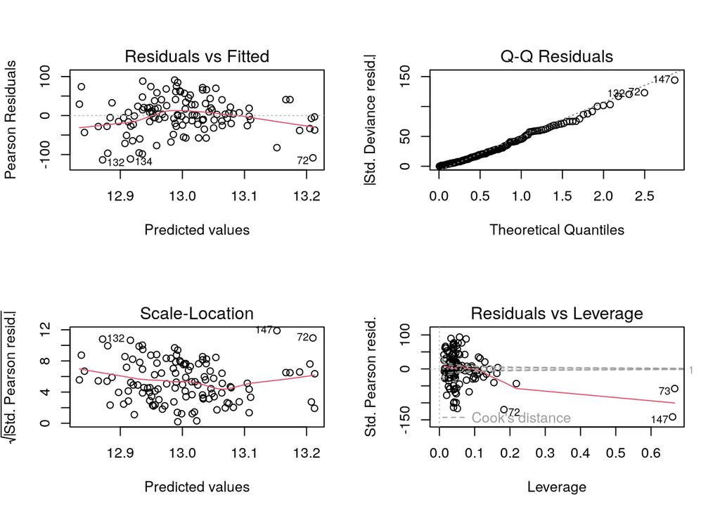

```
## $Dispersion_Test
##
##  Overdispersion test
##
## data:  glm
## z = 7.7709, p-value = 3.896e-15
## alternative hypothesis: true dispersion is greater than 1
## sample estimates:
## dispersion
##   2013.342
##
##
## $AIC
## [1] 245743.8
##
## $Pseudo_R2
## [1] 0.6007588
##
## $Test_Correlation
## [1] 0.7697397
##
## $Residuals_vs_Predicted_Plot
## [1] "See plot output"
```

```r
check_glm(glm_poisson, data_total, seed, TRUE)
```

```r
# Negative binomial GLM
glm_nb <- glm.nb(Total.offences ~ ., data = data_total)
summary(glm_nb)
```

```
##
## Call:
## glm.nb(formula = Total.offences ~ ., data = data_total, init.theta = 211.4369802,
##     link = log)
##
## Coefficients:
##                                                                             Estimate
## (Intercept)                                                                1.268e+01
## Births_Total_x                                                             5.009e-06
## Germans_Total_Departures.to.foreign.countries                             -1.353e-05
## Foreigners_Total_Arrivals.from.foreign.countries                           7.299e-07
## Foreigners_Total_Departures.to.foreign.countries                           4.320e-06
## Turnover.in.retail.trade                                                  -1.826e-03
## Energy.and.water.supply..Index.coll..agreed.monthly.earnings.with.sp.pay. -1.004e-03
## Construction..Index.coll..agreed.monthly.earnings.with.sp.pay.             1.703e-03
##                                                                           Std. Error
## (Intercept)                                                                1.145e-01
## Births_Total_x                                                             1.441e-06
## Germans_Total_Departures.to.foreign.countries                              2.012e-06
## Foreigners_Total_Arrivals.from.foreign.countries                           1.232e-07
## Foreigners_Total_Departures.to.foreign.countries                           6.588e-07
## Turnover.in.retail.trade                                                   5.214e-04
## Energy.and.water.supply..Index.coll..agreed.monthly.earnings.with.sp.pay.  5.044e-04
## Construction..Index.coll..agreed.monthly.earnings.with.sp.pay.             8.239e-04
##                                                                           z value
## (Intercept)                                                               110.773
## Births_Total_x                                                              3.475
## Germans_Total_Departures.to.foreign.countries                              -6.726
## Foreigners_Total_Arrivals.from.foreign.countries                            5.927
## Foreigners_Total_Departures.to.foreign.countries                            6.557
## Turnover.in.retail.trade                                                   -3.502
## Energy.and.water.supply..Index.coll..agreed.monthly.earnings.with.sp.pay.  -1.990
## Construction..Index.coll..agreed.monthly.earnings.with.sp.pay.              2.067
##                                                                           Pr(>|z|)
## (Intercept)                                                                < 2e-16
## Births_Total_x                                                            0.000511
## Germans_Total_Departures.to.foreign.countries                             1.74e-11
## Foreigners_Total_Arrivals.from.foreign.countries                          3.09e-09
## Foreigners_Total_Departures.to.foreign.countries                          5.49e-11
## Turnover.in.retail.trade                                                  0.000461
```

[output cut: 12 more lines]

```
## Signif. codes:  0 '***' 0.001 '**' 0.01 '*' 0.05 '.' 0.1 ' ' 1
##
## (Dispersion parameter for Negative Binomial(211.437) family taken to be 1)
##
##     Null deviance: 296.61  on 119  degrees of freedom
## Residual deviance: 120.10  on 112  degrees of freedom
## AIC: 2836
##
## Number of Fisher Scoring iterations: 1
##
##
##               Theta:  211.4
##           Std. Err.:  27.3
##
##  2 x log-likelihood:  -2817.959
```

[figure not shown]

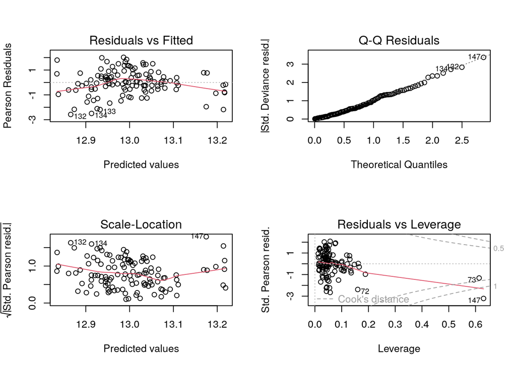

```
## $Dispersion_Test
## NULL
##
## $AIC
## [1] 2835.959
##
## $Pseudo_R2
## [1] 0.5950991
##
## $Test_Correlation
## [1] 0.7604825
##
## $Residuals_vs_Predicted_Plot
## [1] "See plot output"
```

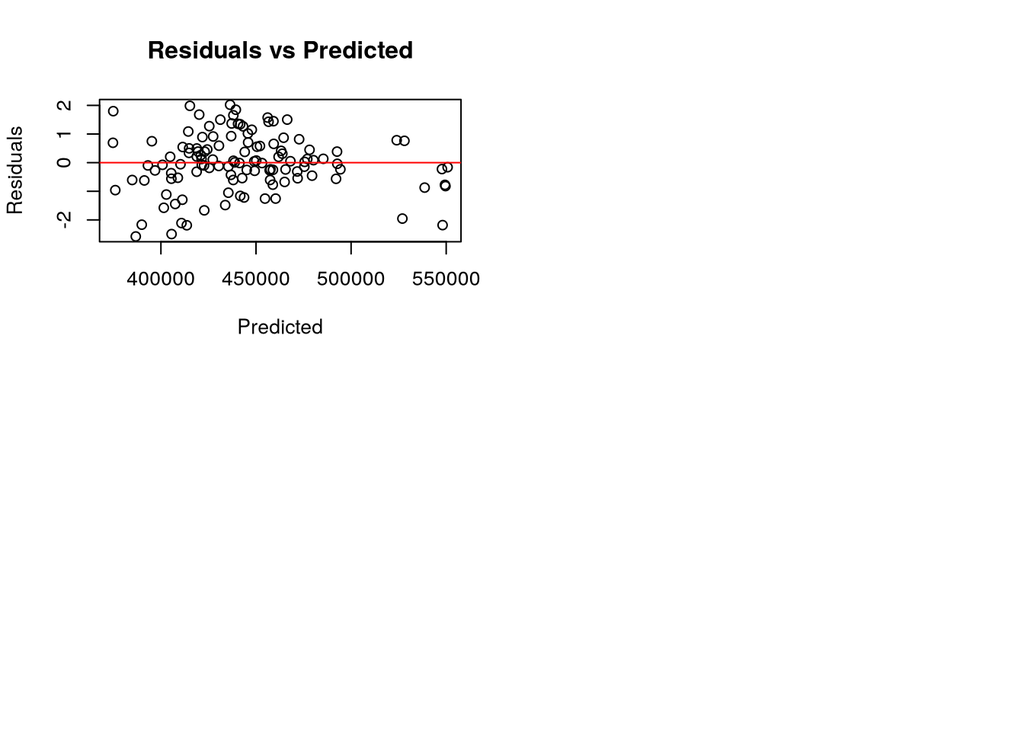

```r
check_glm(glm_nb, data_total, seed, FALSE)
```

VISUALISATION______________________________________

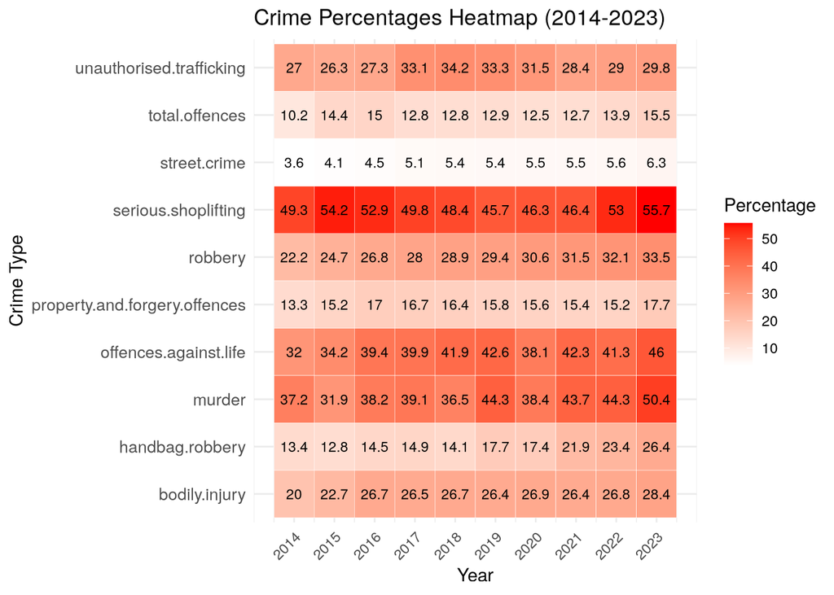

```r
visualise_crime_percentages_heatmap(non_german_percentage)
```